# MSDS 430 Milestone 2

#### Complete the following step by step instructions and submit your notebook and data file to Canvas. Your completed notebook should include all output, i.e. run each cell and save your file before submitting.

In this second milestone we will continue working toward the final project for this course. By now you should have a very clear picture of your plans for the final project, so these steps will simply walk you through some of the work.

Step 1 (5 pts.): In Milestone 1, you gave a brief summary of your overall plans for the final project. What has changed since then? Has your problem changed? Did you choose a different data set? Why or why not? What additional detail can you provide with regard to your goals for the final project?

I will use King County (Greater Seattle) house sale prices: https://www.kaggle.com/harlfoxem/housesalesprediction. It has about 20 property features/details for 21613 residential property transactions between May 2014 and May 2015. I'm interested in knowing about if the house sale price correlate to additional amenities such as the number of bedrooms, sq. ft. of living space, and other features. I also would like to explore how location/views can impact on house sales by using geographic heatmap (https://alcidanalytics.com/p/geographic-heatmap-in-python).

The size of data changed: I was able to remove outliers (reduced rows by 5%) and also able to down select property features from 21 to 9 (reduced columns by 57%):

- date
- price
- bedrooms
- bathrooms
- sqft_living
- waterfront
- view
- geo indicators: latitude and longitude

My housing assignment has not changed, and I did not choose a different data set because I was able to use feature extraction and percentile to extract important features of the data.

I would like to find answers to the following questions (my goals) for the final project:

- What month was the busiest month for selling houses
- Do number of bedrooms stay as price increases
- What are the expensive neighborhoods
- what are the larger living space and 3+ bedroom neighborhoods

Step 2 (5 pts.): Read in your data file and use pandas and clean up your data as needed. Extract only what you will be using for this project and demonstrate this by creating a nicely formatted table of the first 20 rows of data relevant to your needs for the project. Each column should align nicely and be clearly labeled. Remember to include any relevant comments within your code.

```python
import pandas as pd
## Read the csv file
house = pd.read_csv('kc_house_data.csv')
house.head()
```

|  | id | date | price | bedrooms | bathrooms | sqft_living | sqft_lot | floors | waterfront | view | ... | grade | sqft_above | sqft_basement | yr_built | yr_renovated | zipcode | lat | long | sqft_living15 | sqft_lot15 |
| --- | --- | --- | --- | --- | --- | --- | --- | --- | --- | --- | --- | --- | --- | --- | --- | --- | --- | --- | --- | --- | --- |
| 0 | 1999700045 | 20140502 | 313000.0 | 3 | 1.50 | 1340 | 7912 | 1.5 | 0 | 0 | ... | 7 | 1340 | 0 | 1955 | 0 | 98133 | 47.7658 | -122.339 | 1480 | 7940 |
| 1 | 1860600135 | 20140502 | 2380000.0 | 5 | 2.50 | 3650 | 9050 | 2.0 | 0 | 4 | ... | 10 | 3370 | 280 | 1921 | 0 | 98119 | 47.6345 | -122.367 | 2880 | 5400 |
| 2 | 5467900070 | 20140502 | 342000.0 | 3 | 2.00 | 1930 | 11947 | 1.0 | 0 | 0 | ... | 8 | 1930 | 0 | 1966 | 0 | 98042 | 47.3672 | -122.151 | 2200 | 12825 |
| 3 | 4040800810 | 20140502 | 420000.0 | 3 | 2.25 | 2000 | 8030 | 1.0 | 0 | 0 | ... | 8 | 1000 | 1000 | 1963 | 0 | 98008 | 47.6188 | -122.114 | 2070 | 8250 |
| 4 | 7197300105 | 20140502 | 550000.0 | 4 | 2.50 | 1940 | 10500 | 1.0 | 0 | 0 | ... | 7 | 1140 | 800 | 1976 | 0 | 98052 | 47.6830 | -122.114 | 2200 | 10500 |

5 rows × 21 columns

#### I will use feature extraction to select important columns

```python
# I will use feature extraction to select important columns
# I have 21 features and I will split the data into three: sqft, views-and-conditions, and the rest (price, rooms, and geographic indicators)

house_viewsConditions = house.iloc[:, house.columns.get_indexer(['waterfront', 'view', 'condition', 'grade', 'yr_built', 'yr_renovated'])]
house_sqft = house.iloc[:, house.columns.get_indexer(['sqft_living', 'sqft_lot', 'floors', 'sqft_above', 'sqft_basement', 'sqft_living15', 'sqft_lot15'])]
house_theRest = house.iloc[:, house.columns.get_indexer(['date','price', 'bedrooms', 'bathrooms', 'zipcode', 'lat', 'long'])]
```

```python
# Feature extraction

# https://www.kaggle.com/sz8416/6-ways-for-feature-selection
# https://scikit-learn.org/stable/modules/feature_selection.html
# https://www.datacamp.com/community/tutorials/feature-selection-python

from sklearn.feature_selection import SelectKBest
from sklearn.feature_selection import chi2

## I'll drop id, and geograhic features
## X, y = house.drop(['id', 'price', 'zipcode', 'lat', 'long'], axis=1), house.price
## X_new = SelectKBest(chi2, k=8).fit_transform(X, y)

X, y  = house_viewsConditions, house.price
chi_selector = SelectKBest(chi2, k=3)
chi_selector.fit(X, y)
chi_support = chi_selector.get_support()
chi_feature = X.loc[:,chi_support].columns.tolist()
print(chi_feature)

X1, y = house_sqft, house.price
chi_selector = SelectKBest(chi2, k=3)
chi_selector.fit(X1, y)
chi_support = chi_selector.get_support()
chi_feature = X1.loc[:,chi_support].columns.tolist()
print(chi_feature)
```

```
['waterfront', 'view', 'yr_renovated']
['sqft_living', 'sqft_lot', 'sqft_lot15']
```

```python
# Feature extraction helped me to identify the most important 6 features: ['waterfront', 'view', 'yr_renovated'] and ['sqft_living', 'sqft_lot', 'sqft_lot15']
# I can further down select and get 3 top features out of them: 'waterfront', 'view', 'sqft_living'
# So we have house_theRest (price, rooms, geo) + waterfront + view + sqft_living
# Now we have 9 total features out of 21

house_df = house.iloc[:, house.columns.get_indexer(['date','price', 'bedrooms', 'bathrooms', 'lat', 'long', 'waterfront', 'view', 'sqft_living'])]
print("A number of rows and columns of house: ", house.shape)
print("A number of rows and columns of house_df: ", house_df.shape)
house_df.head(20)
```

```
A number of rows and columns of house:  (21613, 21)
A number of rows and columns of house_df:  (21613, 9)
```

|  | date | price | bedrooms | bathrooms | lat | long | waterfront | view | sqft_living |
| --- | --- | --- | --- | --- | --- | --- | --- | --- | --- |
| 0 | 20140502 | 313000.0 | 3 | 1.50 | 47.7658 | -122.339 | 0 | 0 | 1340 |
| 1 | 20140502 | 2380000.0 | 5 | 2.50 | 47.6345 | -122.367 | 0 | 4 | 3650 |
| 2 | 20140502 | 342000.0 | 3 | 2.00 | 47.3672 | -122.151 | 0 | 0 | 1930 |
| 3 | 20140502 | 420000.0 | 3 | 2.25 | 47.6188 | -122.114 | 0 | 0 | 2000 |
| 4 | 20140502 | 550000.0 | 4 | 2.50 | 47.6830 | -122.114 | 0 | 0 | 1940 |
| 5 | 20140502 | 490000.0 | 2 | 1.00 | 47.6924 | -122.322 | 0 | 0 | 880 |
| 6 | 20140502 | 335000.0 | 2 | 2.00 | 47.6344 | -122.107 | 0 | 0 | 1350 |
| 7 | 20140502 | 482000.0 | 4 | 2.50 | 47.3750 | -122.022 | 0 | 0 | 2710 |
| 8 | 20140502 | 452500.0 | 3 | 2.50 | 47.4828 | -121.718 | 0 | 0 | 2430 |
| 9 | 20140502 | 640000.0 | 4 | 2.00 | 47.6780 | -122.269 | 0 | 0 | 1520 |
| 10 | 20140502 | 463000.0 | 3 | 1.75 | 47.7512 | -122.281 | 0 | 0 | 1710 |
| 11 | 20140502 | 1400000.0 | 4 | 2.50 | 47.6578 | -122.280 | 0 | 0 | 2920 |
| 12 | 20140502 | 588500.0 | 3 | 1.75 | 47.6267 | -122.046 | 0 | 0 | 2330 |
| 13 | 20140502 | 365000.0 | 3 | 1.00 | 47.5334 | -122.365 | 0 | 0 | 1090 |
| 14 | 20140502 | 1200000.0 | 5 | 2.75 | 47.6552 | -122.278 | 0 | 0 | 2910 |
| 15 | 20140502 | 242500.0 | 3 | 1.50 | 47.4225 | -122.153 | 0 | 0 | 1200 |
| 16 | 20140502 | 419000.0 | 3 | 1.50 | 47.6022 | -122.134 | 0 | 0 | 1570 |
| 17 | 20140502 | 285000.0 | 4 | 2.50 | 47.3406 | -122.269 | 0 | 0 | 2200 |
| 18 | 20140502 | 367500.0 | 4 | 3.00 | 47.3279 | -122.191 | 0 | 0 | 3110 |
| 19 | 20140502 | 257950.0 | 3 | 1.75 | 47.3815 | -122.313 | 0 | 0 | 1370 |

Step 3 (5 pts.): Use numpy and the cleaned data to perform several calculations relevant to your final project. Explain each calculation by including comments within your code. Your output should clearly state what each calculation is, i.e. "The mean height of those in the data is X"

#### I was able to downsize the columns, now I need to remove the outliers from the rows:

```python
import numpy as np

# I was able to downsize the columns, now I need to remove the outliers from the rows
# I can detect/identify outliers by calculating statistics for each row
house_df_analysis = house_df.drop(['date', 'lat','long'], axis=1)

stats = np.round(house_df_analysis.describe())
# append medium calc to describe()
medians = house_df_analysis.median()
stats.loc['median'] = medians
stats

# waterfront is binary (0 and 1) and view is categorical (from 0 to 4) data. Statistical interpretations do not apply for them
# data skewed if the mean is not equal to the median: price, and sqft_living
# I can also compare 75% percentile to max. I can spot outlier values of bedrooms, bathrooms, price, and sqft_living
```

|  | price | bedrooms | bathrooms | waterfront | view | sqft_living |
| --- | --- | --- | --- | --- | --- | --- |
| count | 21613.0 | 21613.0 | 21613.00 | 21613.0 | 21613.0 | 21613.0 |
| mean | 540182.0 | 3.0 | 2.00 | 0.0 | 0.0 | 2080.0 |
| std | 367362.0 | 1.0 | 1.00 | 0.0 | 1.0 | 918.0 |
| min | 75000.0 | 0.0 | 0.00 | 0.0 | 0.0 | 290.0 |
| 25% | 321950.0 | 3.0 | 2.00 | 0.0 | 0.0 | 1427.0 |
| 50% | 450000.0 | 3.0 | 2.00 | 0.0 | 0.0 | 1910.0 |
| 75% | 645000.0 | 4.0 | 2.00 | 0.0 | 0.0 | 2550.0 |
| max | 7700000.0 | 33.0 | 8.00 | 1.0 | 4.0 | 13540.0 |
| median | 450000.0 | 3.0 | 2.25 | 0.0 | 0.0 | 1910.0 |

```python
## https://stackoverflow.com/questions/23199796/detect-and-exclude-outliers-in-pandas-data-frame
## keep only the ones that are within +3 to -3 standard deviations in the column 'Data'
## house_df[np.abs(house_df-house_df.mean()) <= (3*house_df.std())]
## house_df[~(np.abs(house_df-house_df.mean()) > (3*house_df.std()))] # or if you prefer the other way around
## house_df[np.abs(house_df.bedrooms-house_df.bedrooms.mean()) <= (4*house_df.bedrooms.std())]
## from scipy import stats
## house1 = house[(np.abs(stats.zscore(house)) < 3).all(axis=1)]

# I'll use percentile to see the extreme outliers
house_df[house_df.price >= np.percentile(house_df.price, 99.95)]
```

|  | date | price | bedrooms | bathrooms | lat | long | waterfront | view | sqft_living |
| --- | --- | --- | --- | --- | --- | --- | --- | --- | --- |
| 2439 | 20140611 | 7060000.0 | 5 | 4.50 | 47.6500 | -122.214 | 1 | 2 | 10040 |
| 2828 | 20140617 | 4670000.0 | 5 | 6.75 | 47.5570 | -122.210 | 1 | 4 | 9640 |
| 2945 | 20140618 | 4490000.0 | 4 | 3.00 | 47.6208 | -122.219 | 0 | 0 | 6430 |
| 6261 | 20140804 | 5570000.0 | 5 | 5.75 | 47.6289 | -122.233 | 0 | 0 | 9200 |
| 7081 | 20140815 | 4500000.0 | 5 | 5.50 | 47.7493 | -122.280 | 1 | 4 | 6640 |
| 9212 | 20140919 | 6890000.0 | 6 | 7.75 | 47.6305 | -122.240 | 0 | 4 | 9890 |
| 10532 | 20141013 | 7700000.0 | 6 | 8.00 | 47.6298 | -122.323 | 0 | 3 | 12050 |
| 10927 | 20141020 | 5110000.0 | 5 | 5.25 | 47.6767 | -122.211 | 1 | 4 | 8010 |
| 19510 | 20150413 | 5300000.0 | 6 | 6.00 | 47.5631 | -122.210 | 1 | 4 | 7390 |
| 19513 | 20150413 | 5350000.0 | 5 | 5.00 | 47.6232 | -122.220 | 0 | 4 | 8000 |
| 21304 | 20150506 | 4210000.0 | 5 | 6.00 | 47.5692 | -122.189 | 0 | 0 | 7440 |

```python
house_df[house_df.bedrooms >= np.percentile(house_df.bedrooms, 99.95)]
```

|  | date | price | bedrooms | bathrooms | lat | long | waterfront | view | sqft_living |
| --- | --- | --- | --- | --- | --- | --- | --- | --- | --- |
| 255 | 20140507 | 599999.0 | 9 | 4.50 | 47.6927 | -122.338 | 0 | 0 | 3830 |
| 3595 | 20140625 | 640000.0 | 33 | 1.75 | 47.6878 | -122.331 | 0 | 0 | 1620 |
| 6610 | 20140808 | 1280000.0 | 9 | 4.50 | 47.6604 | -122.289 | 0 | 0 | 3650 |
| 6715 | 20140811 | 450000.0 | 9 | 7.50 | 47.5923 | -122.301 | 0 | 0 | 4050 |
| 7035 | 20140814 | 1150000.0 | 10 | 5.25 | 47.5861 | -122.113 | 0 | 2 | 4590 |
| 7468 | 20140821 | 520000.0 | 11 | 3.00 | 47.5560 | -122.363 | 0 | 0 | 3000 |
| 11591 | 20141029 | 650000.0 | 10 | 2.00 | 47.5705 | -122.175 | 0 | 0 | 3610 |
| 14534 | 20141229 | 660000.0 | 10 | 3.00 | 47.6635 | -122.320 | 0 | 0 | 2920 |
| 14746 | 20150106 | 700000.0 | 9 | 3.00 | 47.6374 | -122.324 | 0 | 0 | 3680 |
| 17582 | 20150313 | 934000.0 | 9 | 3.00 | 47.6654 | -122.307 | 0 | 0 | 2820 |
| 17753 | 20150317 | 1400000.0 | 9 | 4.00 | 47.6684 | -122.309 | 0 | 0 | 4620 |

```python
house_df[house_df.bathrooms >= np.percentile(house_df.bathrooms, 99.95)]
```

|  | date | price | bedrooms | bathrooms | lat | long | waterfront | view | sqft_living |
| --- | --- | --- | --- | --- | --- | --- | --- | --- | --- |
| 130 | 20140505 | 2280000.0 | 7 | 8.00 | 47.6675 | -121.986 | 0 | 4 | 13540 |
| 496 | 20140509 | 2240000.0 | 5 | 6.50 | 47.5371 | -121.982 | 0 | 0 | 7270 |
| 2484 | 20140611 | 2890000.0 | 5 | 6.25 | 47.7295 | -122.372 | 0 | 4 | 8670 |
| 2828 | 20140617 | 4670000.0 | 5 | 6.75 | 47.5570 | -122.210 | 1 | 4 | 9640 |
| 4134 | 20140702 | 3300000.0 | 5 | 6.25 | 47.5675 | -122.189 | 0 | 0 | 8020 |
| 6715 | 20140811 | 450000.0 | 9 | 7.50 | 47.5923 | -122.301 | 0 | 0 | 4050 |
| 7622 | 20140822 | 1490000.0 | 5 | 6.00 | 47.4624 | -121.779 | 0 | 3 | 6880 |
| 9212 | 20140919 | 6890000.0 | 6 | 7.75 | 47.6305 | -122.240 | 0 | 4 | 9890 |
| 10194 | 20141007 | 800000.0 | 7 | 6.75 | 47.4643 | -122.368 | 0 | 2 | 7480 |
| 10196 | 20141007 | 2150000.0 | 8 | 6.00 | 47.6316 | -122.202 | 0 | 0 | 4340 |
| 10508 | 20141011 | 3640000.0 | 5 | 6.00 | 47.6165 | -122.236 | 0 | 0 | 5490 |
| 10532 | 20141013 | 7700000.0 | 6 | 8.00 | 47.6298 | -122.323 | 0 | 3 | 12050 |
| 16390 | 20150219 | 900000.0 | 5 | 6.00 | 47.5451 | -122.114 | 0 | 4 | 7120 |
| 18562 | 20150328 | 1180000.0 | 6 | 6.50 | 47.5947 | -122.039 | 0 | 0 | 6260 |
| 19510 | 20150413 | 5300000.0 | 6 | 6.00 | 47.5631 | -122.210 | 1 | 4 | 7390 |
| 21304 | 20150506 | 4210000.0 | 5 | 6.00 | 47.5692 | -122.189 | 0 | 0 | 7440 |

```python
house_df[house_df.sqft_living >= np.percentile(house_df.sqft_living, 99.95)]
```

|  | date | price | bedrooms | bathrooms | lat | long | waterfront | view | sqft_living |
| --- | --- | --- | --- | --- | --- | --- | --- | --- | --- |
| 130 | 20140505 | 2280000.0 | 7 | 8.00 | 47.6675 | -121.986 | 0 | 4 | 13540 |
| 2439 | 20140611 | 7060000.0 | 5 | 4.50 | 47.6500 | -122.214 | 1 | 2 | 10040 |
| 2484 | 20140611 | 2890000.0 | 5 | 6.25 | 47.7295 | -122.372 | 0 | 4 | 8670 |
| 2828 | 20140617 | 4670000.0 | 5 | 6.75 | 47.5570 | -122.210 | 1 | 4 | 9640 |
| 4134 | 20140702 | 3300000.0 | 5 | 6.25 | 47.5675 | -122.189 | 0 | 0 | 8020 |
| 6261 | 20140804 | 5570000.0 | 5 | 5.75 | 47.6289 | -122.233 | 0 | 0 | 9200 |
| 9212 | 20140919 | 6890000.0 | 6 | 7.75 | 47.6305 | -122.240 | 0 | 4 | 9890 |
| 10532 | 20141013 | 7700000.0 | 6 | 8.00 | 47.6298 | -122.323 | 0 | 3 | 12050 |
| 10927 | 20141020 | 5110000.0 | 5 | 5.25 | 47.6767 | -122.211 | 1 | 4 | 8010 |
| 15596 | 20150130 | 2420000.0 | 5 | 4.75 | 47.7334 | -122.362 | 0 | 2 | 7880 |
| 19513 | 20150413 | 5350000.0 | 5 | 5.00 | 47.6232 | -122.220 | 0 | 4 | 8000 |

#### Now I can remove the extreme outliers.

*I could have used the loop, but I would like to see the step by step process*

```python
# Now I can remove the extreme outliers. I could have used the loop, but I would like to see the step by step process:
house_df1 = house_df[house_df.price <= np.percentile(house_df.price, 95)]
house_df2 = house_df1[house_df1.bedrooms <= np.percentile(house_df1.bedrooms, 99.95)]
house_df3 = house_df2[house_df2.bathrooms <= np.percentile(house_df2.bathrooms, 99.95)]
house_df4 = house_df3[house_df3.sqft_living <= np.percentile(house_df3.sqft_living, 99.95)]
```

```python
print(house_df.shape)
print(house_df4.shape)

# I was able to remove 1,094(5%) extreme oulier rows out of 21,613 rows
```

```
(21613, 9)
(20519, 9)
```

```python
# now our statistics (max row) look much better after removing the outliers
house_df4_analysis = house_df4.drop(['date', 'lat','long'], axis=1)

np.round(house_df4_analysis.describe())
```

|  | price | bedrooms | bathrooms | waterfront | view | sqft_living |
| --- | --- | --- | --- | --- | --- | --- |
| count | 20519.0 | 20519.0 | 20519.0 | 20519.0 | 20519.0 | 20519.0 |
| mean | 479105.0 | 3.0 | 2.0 | 0.0 | 0.0 | 1978.0 |
| std | 211669.0 | 1.0 | 1.0 | 0.0 | 1.0 | 775.0 |
| min | 75000.0 | 0.0 | 0.0 | 0.0 | 0.0 | 290.0 |
| 25% | 315000.0 | 3.0 | 2.0 | 0.0 | 0.0 | 1400.0 |
| 50% | 438400.0 | 3.0 | 2.0 | 0.0 | 0.0 | 1860.0 |
| 75% | 604000.0 | 4.0 | 2.0 | 0.0 | 0.0 | 2440.0 |
| max | 1160000.0 | 8.0 | 5.0 | 1.0 | 4.0 | 5670.0 |

Step 4 (5 pts.): Use matplotlib to create at least two visual displays relevant to your final project. Explain your graphs by including comments within your code. Your displays should be labeled clearly and appropriately scaled.

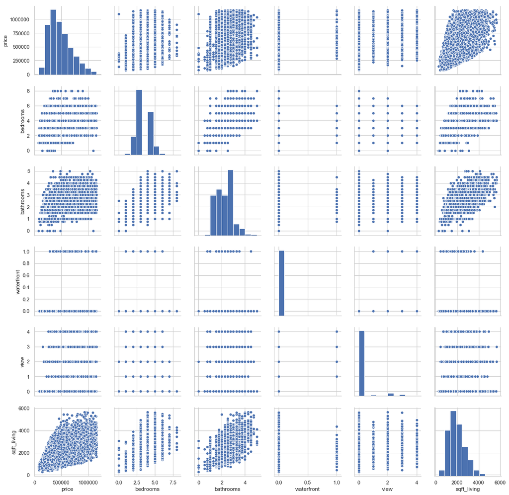

```python
import seaborn as sns
import matplotlib.pyplot as plt

sns.set(style="white") #white background style for seaborn plots
sns.set(style="whitegrid", color_codes=False)

sns.pairplot(house_df4_analysis, kind="scatter")
plt.show()

# Pair plot and scatter plot of the the data where outliers and less important columns removed.
# I can see strong correlations bewteen proprty price and living space
```

```
 <a list of 16 Text xticklabel objects>)
```

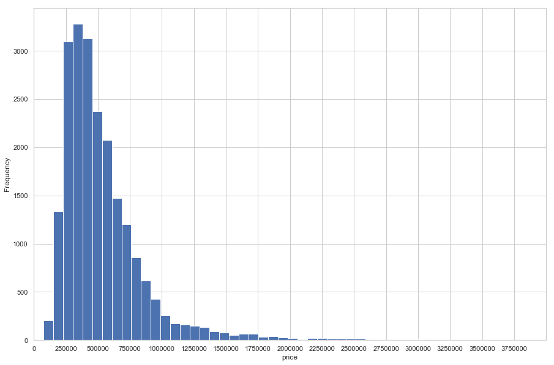

```python
# with outliers
## http://pandas.pydata.org/pandas-docs/version/0.15.0/visualization.html
## here is an easiest way of plotting house price in a histogram distribution
house_df.price.plot(kind='hist', figsize=(15, 10), bins=100)

## additional plot features
plt.xlabel('price',  fontsize = 12)
plt.xlim(0, 4000000) # up t0 $4,000,000
plt.xticks(np.arange(0, 4000000, 250000))
```

```
 <a list of 13 Text xticklabel objects>)
```

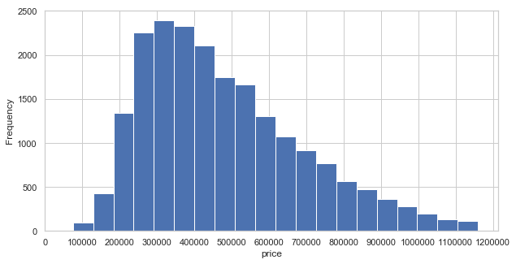

```python
# without outliers
house_df4.price.plot(kind='hist', figsize=(10, 5), bins=20)
plt.xlabel('price',  fontsize = 12)
plt.xticks(np.arange(0, 1250000, 100000))

# Around 2014 and 2015 at King County (greater Seattle Area), the most frequently sold properties were at price range of $300k and $400k
# After $400k price, the property availability decreases for each $100k price increase
```

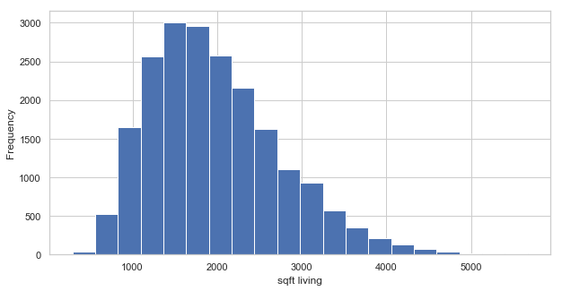

```python
house_df4.sqft_living.plot(kind='hist', figsize=(10, 5), bins=20)
plt.xlabel('sqft living',  fontsize = 12)

# Around 2014 and 2015 at King County (greater Seattle Area), the most frequently sold properties were at living space range of 1500 sqft and 2000 sqft
# After 2000 sqft, the property availability decreases for each additional 500 sqft increase
```

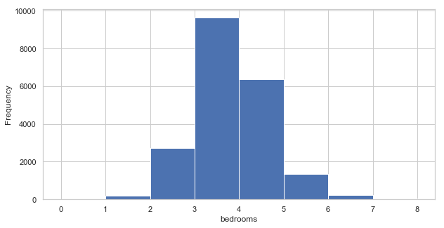

```python
house_df4.bedrooms.plot(kind='hist', figsize=(10, 5), bins=8)
plt.xlabel('bedrooms',  fontsize = 12)
# there are more 3 bedroom houses
```

```python
# reformat the date and extract month and year
## house_df4['date1'] = pd.to_datetime(house_df4.date, format='%Y%m%d', errors='ignore').dt.month
house_df4.date = pd.to_datetime(house_df4.date, format='%Y%m%d', errors='ignore')
house_df4['date2'] = pd.to_datetime(house_df4.date, format='%Y%m%d', errors='ignore').dt.to_period('M')

# pivot price by month and year
## test1 = pd.pivot_table(house_df4, index= 'date2', values= "price", aggfunc=np.sum)
test1 = pd.pivot_table(house_df4, index= 'date2', values= "price", aggfunc='count')
```

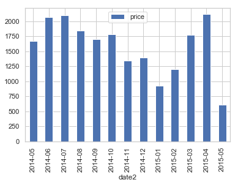

```python
test1.plot(kind= 'bar')
# The slowest months were during fall and winter seasons. April, June, and July months were the busiest times.
```